# Texas Machine Learning 4: Classification for Fumonisin

Xianbin Cheng

12/19/2019

# Objective

- Train models that can classify kernels by fumonisin levels with high sensitivity and specificity (with ROC as the cross validation metric)

# Method

1. Read files and load libraries.

```r
library(tidyverse)
library(caret)
library(randomForest)
library(gbm)
library(glmnet)
library(kernlab)
library(MASS)
library(stepPlr)
library(nnet)
library(adabag)
library(kableExtra)
```

```r
norm_data = read_csv(file = "tx x_norm_conc_1680_obs.csv")
FM_class = norm_data$FM_class
FM_class[FM_class == "M"] = "H"
spec_data = norm_data %>%
  dplyr::select(-c(X1, Kernel_ID, AF_class, FM_class, Spec_ID_all)) %>%
  as.matrix()

str(norm_data, list.len = 8, give.attr = FALSE)
```

```
## Classes 'spec_tbl_df', 'tbl_df', 'tbl' and 'data.frame': 1680 obs. of  1570 variables:
##  $ X1         : num  1 2 3 4 5 6 7 8 9 10 ...
##  $ Kernel_ID  : chr  "101-1" "101-2" "101-3" "101-4" ...
##  $ AF_class   : chr  "L" "L" "L" "L" ...
##  $ FM_class   : chr  "L" "L" "L" "L" ...
##  $ Spec_ID_all: chr  "LL1-000001.dat" "LL1-000002.dat" "LL1-000003.dat" "LL1-000004.dat" ...
##  $ X304       : num  -0.782 -1.115 -1.18 -0.202 -0.857 ...
##  $ X304.5     : num  -0.464 -1.166 -0.76 -0.385 -0.923 ...
##  $ X305       : num  -0.364 -1.193 -0.617 -0.503 -0.986 ...
##   [list output truncated]
```

```r
summary(as.factor(FM_class))
```

```
##    H    L
##   94 1586
```

2. Train models
- Train-test split ratio = 7:3
- Up-sampling of the minority class in the training set
- 5-fold cross-validation
- Using “ROC” as a metric for parameter tuning
- Algorithms:
  - Bagged Adaboost
  - Stochastic gradient boosting
  - Logistic regression with LASSO
  - LDA
  - Random forest
  - Logistic regression with l2 norm
  - SVM with polynomial kernel
  - SVM with radial basis function kernel

```r
set.seed(123)
trn_idx = createDataPartition(y = FM_class, p = 0.7, list = FALSE)
trn_data = spec_data[trn_idx, ]
tst_data = spec_data[-trn_idx, ]
trn_FM = FM_class[trn_idx] %>% as.factor()
tst_FM = FM_class[-trn_idx] %>% as.factor()
summary(trn_FM)
```

```
##    H    L
##   66 1111
```

```r
summary(tst_FM)
```

```
##   H   L
##  28 475
```

```r
# Up sampling of the minority class
resamp = upSample(x = trn_data, y = trn_FM)
trn_data_samp = dplyr::select(.data = resamp, -Class) %>% as.matrix()
trn_FM_samp = resamp$Class
summary(trn_FM_samp)
```

```
##    H    L
## 1111 1111
```

```r
# TrainControl
cv_5 = trainControl(method = "cv", number = 5, classProbs = TRUE, summaryFunction = twoClassSummary, verboseIter = FALSE)
```

```r
# Logisitic regression with LASSO
set.seed(123)
cv.mod = cv.glmnet(x = trn_data_samp, y = trn_FM_samp, type.measure = "auc", family = "binomial", alpha = 1)
mod_glmnet = glmnet(x = trn_data_samp, y = trn_FM_samp, family = "binomial", alpha = 1, lambda = cv.mod$lambda.min)
saveRDS(object = mod_glmnet, file = "mod_glmnet_fm_roc.rds")

# gradient stochastic boosting
set.seed(123)
mod_gbm = train(x = trn_data_samp,
                y = trn_FM_samp,
                method = "gbm",
                preProcess = NULL,
                metric = "ROC",
                trControl = cv_5,
                tuneGrid = expand.grid(shrinkage = c(0.01, 0.1), n.minobsinnode = 10, n.trees = c(100, 150, 200), interaction.depth = c(1, 2)))
saveRDS(object = mod_gbm, file = "mod_gbm_fm_roc.rds")

# SVM
set.seed(123)
mod_svm_poly = train(x = trn_data_samp,
                    y = trn_FM_samp,
                    method = "svmPoly",
                    preProcess = NULL,
                    metric = "ROC",
                    trControl = cv_5)
saveRDS(object = mod_svm_poly, file = "mod_svm_poly_fm_roc.rds")

set.seed(123)
mod_svm_rad = train(x = trn_data_samp,
                    y = trn_FM_samp,
                    method = "svmRadial",
                    preProcess = NULL,
                    metric = "ROC",
                    trControl = cv_5,
                    tuneLength = 6)
saveRDS(object = mod_svm_rad, file = "mod_svm_rad_fm_roc.rds")

# Random forest
set.seed(123)
mod_rf = train(x = trn_data_samp,
                    y = trn_FM_samp,
                    method = "rf",
                    preProcess = NULL,
                    metric = "ROC",
                    trControl = cv_5,
                    tuneGrid = expand.grid(mtry = c(2, sqrt(ncol(trn_data_samp)), ncol(trn_data_samp) - 1)))
saveRDS(object = mod_rf, file = "mod_rf_fm_roc.rds")

# LDA
set.seed(123)
mod_lda = train(x = trn_data_samp,
                    y = trn_FM_samp,
                    method = "lda",
                    preProcess = NULL,
                    metric = "ROC",
                    trControl = cv_5)
saveRDS(object = mod_lda, file = "mod_lda_fm_roc.rds")

# penalized logistic regression (l2 norm)
set.seed(123)
mod_logi = train(x = trn_data_samp,
                    y = trn_FM_samp,
                    method = "plr",
                    preProcess = NULL,
                    metric = "ROC",
                    trControl = cv_5)
saveRDS(object = mod_logi, file = "mod_logi_fm_roc.rds")

# Adabag
set.seed(123)
mod_ada = train(x = trn_data_samp,
                    y = trn_FM_samp,
                    method = "AdaBag",
                    preProcess = NULL,
                    metric = "ROC",
                    trControl = cv_5)
saveRDS(object = mod_ada, file = "mod_ada_fm_roc.rds")

##### nnet failed
# set.seed(123)
# mod_nnet = nnet(x = trn_data_samp, y = trn_FM_samp, size = 1, MaxNWts = 1600)

# QDA (collinear variables --> failed)
```

# Result

Training and testing sensitivity and specificity values of each model with tuned parameters are shown here.

| Model | Parameters | Dataset | Accuracy | Sensitivity | Specificity |
| --- | --- | --- | --- | --- | --- |
| Ada | mfinal = 100, maxdepth = 3 | training | 0.8683 | 0.7576 | 0.8749 |
| Ada | mfinal = 100, maxdepth = 3 | testing | 0.8270 | 0.4643 | 0.8484 |
| gbm | n.trees = 200, interaction.depth = 2, shrinkage = 0.1, n.minobsinnode = 10 | training | 0.9890 | 1.0000 | 0.9883 |
| gbm | n.trees = 200, interaction.depth = 2, shrinkage = 0.1, n.minobsinnode = 10 | testing | 0.9324 | 0.3214 | 0.9684 |
| LASSO | character(0) | training | 1.0000 | 1.0000 | 1.0000 |
| LASSO | character(0) | testing | 0.9006 | 0.2143 | 0.9411 |
| LDA | parameter = 1 | training | 0.9839 | 1.0000 | 0.9829 |
| LDA | parameter = 1 | testing | 0.8827 | 0.4286 | 0.9095 |
| logistic | lambda = 1e-04, cp = 1 | training | 1.0000 | 1.0000 | 1.0000 |
| logistic | lambda = 1e-04, cp = 1 | testing | 0.9085 | 0.2143 | 0.9495 |
| rf | mtry = 2 | training | 1.0000 | 1.0000 | 1.0000 |
| rf | mtry = 2 | testing | 0.9523 | 0.1786 | 0.9979 |
| SVM_poly | degree = 3, scale = 0.01, C = 0.25 | training | 0.9992 | 1.0000 | 0.9991 |
| SVM_poly | degree = 3, scale = 0.01, C = 0.25 | testing | 0.9225 | 0.3214 | 0.9579 |
| SVM_radial | sigma = 0.00233500567713234, C = 8 | training | 0.9932 | 1.0000 | 0.9928 |
| SVM_radial | sigma = 0.00233500567713234, C = 8 | testing | 0.9423 | 0.2500 | 0.9832 |

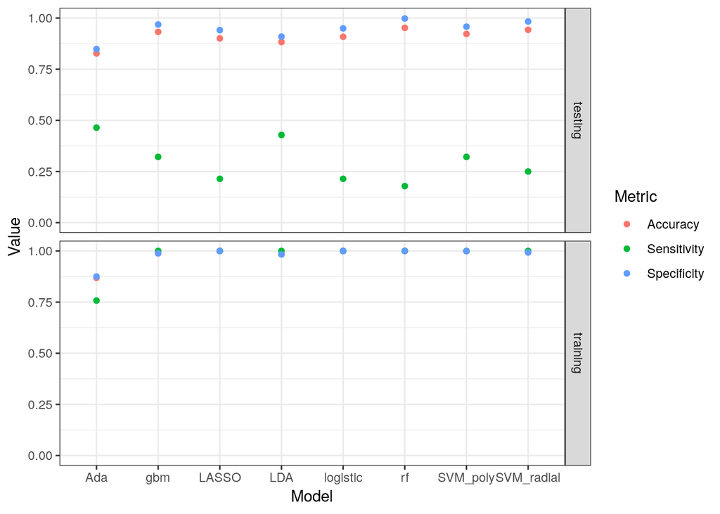

# Conclusion

- The **Bagged Adaboost** model is optimal with a test sensitivity of 0.4643 and a specificity of 0.8484.
- Besides the bagged Adaboost model, LDA may have the potential to get higher test sensitivity values with the proper tuning.
- Overfitting to the training set is a serious problem.

# Appendix

1. The details of parameter tuning of each model are presented here.

```
## Bagged AdaBoost
##
## 2222 samples
## 1565 predictors
##    2 classes: 'H', 'L'
##
## No pre-processing
## Resampling: Cross-Validated (5 fold)
## Summary of sample sizes: 1777, 1778, 1777, 1778, 1778
## Resampling results across tuning parameters:
##
##   maxdepth  mfinal  ROC        Sens       Spec
##   1          50     0.7639857  0.5419182  0.8596332
##   1         100     0.7638062  0.5436917  0.8596211
##   1         150     0.7636090  0.5481962  0.8596291
##   2          50     0.8759101  0.6697734  0.8496909
##   2         100     0.8748056  0.6787379  0.8389003
##   2         150     0.8754472  0.6940209  0.8398012
##   3          50     0.9271414  0.8020886  0.8676928
##   3         100     0.9312873  0.8047913  0.8731144
##   3         150     0.9311525  0.8119985  0.8686099
##
## ROC was used to select the optimal model using the largest value.
## The final values used for the model were mfinal = 100 and maxdepth = 3.
```

```
## Stochastic Gradient Boosting
##
## 2222 samples
## 1565 predictors
##    2 classes: 'H', 'L'
##
## No pre-processing
## Resampling: Cross-Validated (5 fold)
## Summary of sample sizes: 1777, 1778, 1777, 1778, 1778
## Resampling results across tuning parameters:
##
##   shrinkage  interaction.depth  n.trees  ROC        Sens       Spec
##   0.01       1                  100      0.8180345  0.6616855  0.7831616
##   0.01       1                  150      0.8356995  0.6904416  0.7804387
##   0.01       1                  200      0.8495771  0.6841272  0.7804387
##   0.01       2                  100      0.9019762  0.8317133  0.8209510
##   0.01       2                  150      0.9178451  0.8776270  0.8155254
##   0.01       2                  200      0.9309445  0.9001576  0.8254111
##   0.10       1                  100      0.9504081  0.9190240  0.8406981
##   0.10       1                  150      0.9743782  0.9783945  0.8749000
##   0.10       1                  200      0.9849487  0.9865026  0.9000848
##   0.10       2                  100      0.9931452  1.0000000  0.9423827
##   0.10       2                  150      0.9963687  1.0000000  0.9567850
##   0.10       2                  200      0.9971217  1.0000000  0.9630873
##
## Tuning parameter 'n.minobsinnode' was held constant at a value of 10
## ROC was used to select the optimal model using the largest value.
## The final values used for the model were n.trees = 200,
##  interaction.depth = 2, shrinkage = 0.1 and n.minobsinnode = 10.
```

```
##
## Call:  glmnet(x = trn_data_samp, y = trn_FM_samp, family = "binomial",      alpha = 1, lambda = cv.mod$lambda.min)
##
##    Df   %Dev    Lambda
## 1 293 0.9827 4.464e-05
```

```
## Linear Discriminant Analysis
##
## 2222 samples
## 1565 predictors
##    2 classes: 'H', 'L'
##
## No pre-processing
## Resampling: Cross-Validated (5 fold)
## Summary of sample sizes: 1777, 1778, 1777, 1778, 1778
## Resampling results:
##
##   ROC        Sens  Spec
##   0.9831555  1     0.8550762
```

```
## Penalized Logistic Regression
##
## 2222 samples
## 1565 predictors
##    2 classes: 'H', 'L'
##
## No pre-processing
## Resampling: Cross-Validated (5 fold)
## Summary of sample sizes: 1777, 1778, 1777, 1778, 1778
## Resampling results across tuning parameters:
##
##   lambda  ROC        Sens  Spec
##   0e+00   0.5000000  NaN         NaN
##   1e-04   0.9842146    1   0.9468872
##   1e-01   0.9841536    1   0.9387751
##
## Tuning parameter 'cp' was held constant at a value of bic
## ROC was used to select the optimal model using the largest value.
## The final values used for the model were lambda = 1e-04 and cp = bic.
```

```
## Random Forest
##
## 2222 samples
## 1565 predictors
##    2 classes: 'H', 'L'
##
## No pre-processing
## Resampling: Cross-Validated (5 fold)
## Summary of sample sizes: 1777, 1778, 1777, 1778, 1778
## Resampling results across tuning parameters:
##
##   mtry        ROC  Sens  Spec
##      2.00000  1    1     0.9882964
##     39.56008  1    1     0.9801883
##   1564.00000  1    1     0.9576900
##
## ROC was used to select the optimal model using the largest value.
## The final value used for the model was mtry = 2.
```

```
## Support Vector Machines with Polynomial Kernel
##
## 2222 samples
## 1565 predictors
##    2 classes: 'H', 'L'
##
## No pre-processing
## Resampling: Cross-Validated (5 fold)
## Summary of sample sizes: 1777, 1778, 1777, 1778, 1778
## Resampling results across tuning parameters:
##
##   degree  scale  C     ROC        Sens       Spec
##   1       0.001  0.25  0.8781105  0.7434937  0.7821719
##   1       0.001  0.50  0.9171225  0.7731790  0.8325657
##   1       0.001  1.00  0.9338198  0.8299398  0.8568699
##   1       0.010  0.25  0.9473872  0.8839171  0.8784632
##   1       0.010  0.50  0.9573932  0.9054822  0.8937745
##   1       0.010  1.00  0.9640946  0.9261746  0.9063750
##   1       0.100  0.25  0.9722591  0.9612976  0.9144750
##   1       0.100  0.50  0.9765808  0.9730093  0.9306751
##   1       0.100  1.00  0.9796974  0.9936937  0.9432796
##   2       0.001  0.25  0.9493934  0.8865834  0.8856785
##   2       0.001  0.50  0.9673715  0.9315841  0.9027795
##   2       0.001  1.00  0.9752977  0.9522927  0.9297742
##   2       0.010  0.25  0.9828139  0.9963964  0.9630833
##   2       0.010  0.50  0.9839584  1.0000000  0.9666828
##   2       0.010  1.00  0.9857785  1.0000000  0.9711873
##   2       0.100  0.25  0.9854589  1.0000000  0.9693855
##   2       0.100  0.50  0.9854589  1.0000000  0.9702824
##   2       0.100  1.00  0.9854589  1.0000000  0.9693855
##   3       0.001  0.25  0.9773414  0.9441967  0.9315800
##   3       0.001  0.50  0.9812641  0.9648931  0.9468832
##   3       0.001  1.00  0.9862237  0.9810972  0.9576859
##   3       0.010  0.25  0.9888644  1.0000000  0.9703026
##   3       0.010  0.50  0.9886002  1.0000000  0.9711995
##   3       0.010  1.00  0.9885921  1.0000000  0.9711995
##   3       0.100  0.25  0.9837049  1.0000000  0.9631035
##   3       0.100  0.50  0.9837029  1.0000000  0.9631035
##   3       0.100  1.00  0.9837029  1.0000000  0.9631035
##
## ROC was used to select the optimal model using the largest value.
## The final values used for the model were degree = 3, scale = 0.01 and C
##  = 0.25.
```

```
## Support Vector Machines with Radial Basis Function Kernel
##
## 2222 samples
## 1565 predictors
##    2 classes: 'H', 'L'
##
## No pre-processing
## Resampling: Cross-Validated (5 fold)
## Summary of sample sizes: 1777, 1778, 1777, 1778, 1778
## Resampling results across tuning parameters:
##
##   C     ROC        Sens       Spec
##   0.25  0.9702831  0.9118127  0.9045691
##   0.50  0.9827530  0.9325173  0.9360805
##   1.00  0.9899611  0.9819981  0.9513796
##   2.00  0.9927454  1.0000000  0.9684887
##   4.00  0.9935901  1.0000000  0.9837959
##   8.00  0.9951412  1.0000000  0.9865026
##
## Tuning parameter 'sigma' was held constant at a value of 0.002335006
## ROC was used to select the optimal model using the largest value.
## The final values used for the model were sigma = 0.002335006 and C = 8.
```